# Exploratory factor analysis and Cronbach’s alpha

Wan Nor Arifin

2017-07-24

# 1 Introduction

You may read my note on [Overview of validity](https://www.dropbox.com/s/qflvzp9m0p0jeh6/An%20overview%20of%20validity%20%28medstats%29.pdf?dl=0).

# 2 Preliminaries

## 2.1 Load libraries

```r
library(foreign)
library(psych)
library(MVN)
```

## 2.2 Load data set

Download data set “Attitude_Statistics v3.sav”.

Read the data set as `data` and import it into a new data frame `data1` after removing **ID** variable. This will make our analysis easier because the column number = question number.

```r
data = read.spss("Attitude_Statistics v3.sav", use.value.labels = F, to.data.frame = T)
head(data)
```

```
##   ID Q1 Q2 Q3 Q4 Q5 Q6 Q7 Q8 Q9 Q10 Q11 Q12
## 1  1  2  3  3  3  4  4  3  3  3   3   4   2
## 2  2  3  2  3  3  4  4  4  3  3   3   4   2
## 3  3  5  4  5  1  1  1  1  4  4   5   1   4
## 4  4  2  2  2  4  3  2  2  2  2   2   3   3
## 5  5  4  1  4  2  5  1  4  5  5   3   4   4
## 6  6  4  4  4  3  4  4  4  3  4   4   4   4
```

```r
data1 = data[-1]  # no ID
dim(data1)
```

```
## [1] 150  12
```

```r
head(data1)
```

```
##   Q1 Q2 Q3 Q4 Q5 Q6 Q7 Q8 Q9 Q10 Q11 Q12
## 1  2  3  3  3  4  4  3  3  3   3   4   2
## 2  3  2  3  3  4  4  4  3  3   3   4   2
## 3  5  4  5  1  1  1  1  4  4   5   1   4
## 4  2  2  2  4  3  2  2  2  2   2   3   3
## 5  4  1  4  2  5  1  4  5  5   3   4   4
## 6  4  4  4  3  4  4  4  3  4   4   4   4
```

# 3 Exploratory factor analysis

## 3.1 Preliminary steps

**Descriptive statistics:**

Check minimum-maximum values per item,

```r
describe(data1)
```

```
##     vars   n mean   sd median trimmed  mad min max range  skew kurtosis
## Q1     1 150 3.13 1.10      3    3.12 1.48   1   5     4 -0.10    -0.73
## Q2     2 150 3.51 1.03      3    3.55 1.48   1   5     4 -0.14    -0.47
## Q3     3 150 3.18 1.03      3    3.17 1.48   1   5     4 -0.03    -0.42
## Q4     4 150 2.81 1.17      3    2.77 1.48   1   5     4  0.19    -0.81
## Q5     5 150 3.31 1.01      3    3.32 1.48   1   5     4 -0.22    -0.48
## Q6     6 150 3.05 1.09      3    3.05 1.48   1   5     4 -0.04    -0.71
## Q7     7 150 2.92 1.19      3    2.92 1.48   1   5     4 -0.04    -1.06
## Q8     8 150 3.33 1.00      3    3.34 1.48   1   5     4 -0.08    -0.12
## Q9     9 150 3.44 1.05      3    3.48 1.48   1   5     4 -0.21    -0.32
## Q10   10 150 3.31 1.10      3    3.36 1.48   1   5     4 -0.22    -0.39
## Q11   11 150 3.35 0.94      3    3.37 1.48   1   5     4 -0.31    -0.33
## Q12   12 150 2.83 0.98      3    2.83 1.48   1   5     4  0.09    -0.68
##       se
## Q1  0.09
## Q2  0.08
## Q3  0.08
## Q4  0.10
## Q5  0.08
## Q6  0.09
## Q7  0.10
## Q8  0.08
## Q9  0.09
## Q10 0.09
## Q11 0.08
## Q12 0.08
```

n (%) of response to options per item,

```r
response.frequencies(data1)
```

```
##              1          2         3         4          5 miss
## Q1  0.07333333 0.22000000 0.3200000 0.2800000 0.10666667    0
## Q2  0.03333333 0.09333333 0.4200000 0.2400000 0.21333333    0
## Q3  0.05333333 0.18000000 0.4133333 0.2400000 0.11333333    0
## Q4  0.14000000 0.28000000 0.3000000 0.1866667 0.09333333    0
## Q5  0.04000000 0.16666667 0.3466667 0.3333333 0.11333333    0
## Q6  0.08000000 0.23333333 0.3333333 0.2600000 0.09333333    0
## Q7  0.13333333 0.26666667 0.2266667 0.2933333 0.08000000    0
## Q8  0.04666667 0.10000000 0.4800000 0.2266667 0.14666667    0
## Q9  0.04666667 0.09333333 0.4200000 0.2533333 0.18666667    0
## Q10 0.07333333 0.10666667 0.4200000 0.2333333 0.16666667    0
## Q11 0.02666667 0.15333333 0.3466667 0.3866667 0.08666667    0
## Q12 0.07333333 0.32666667 0.3333333 0.2333333 0.03333333    0
```

**Normality of data**

Univariate normality

1. Histograms

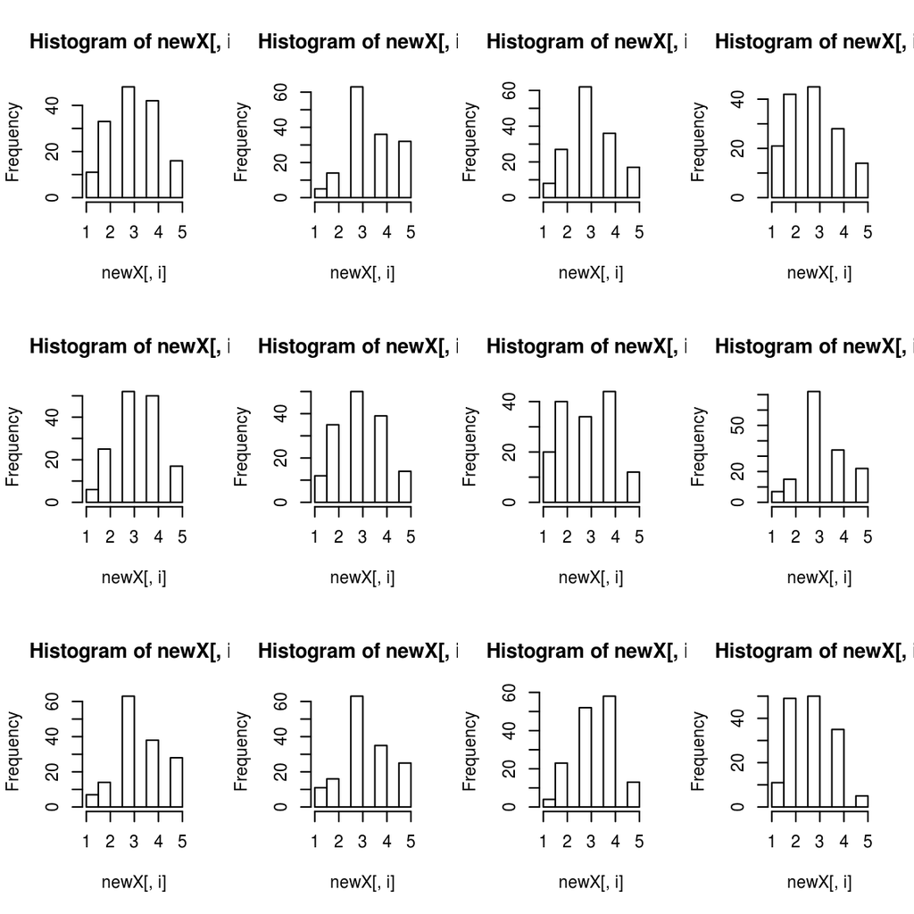

```r
par(mfrow = c(3,4))  # set view to 3 rows & 4 columns
apply(data1, 2, hist)
```

```r
par(mfrow = c(1,1))  # set to default full view
# multi.hist(data1)  # at times, error
```

2. Shapiro Wilk’s test

```r
apply(data1, 2, shapiro.test)
```

```
## $Q1
##
##  Shapiro-Wilk normality test
##
## data:  newX[, i]
## W = 0.91535, p-value = 1.075e-07
##
##
## $Q2
##
##  Shapiro-Wilk normality test
##
## data:  newX[, i]
## W = 0.88321, p-value = 1.656e-09
##
##
## $Q3
##
##  Shapiro-Wilk normality test
##
## data:  newX[, i]
## W = 0.90785, p-value = 3.76e-08
##
##
## $Q4
##
##  Shapiro-Wilk normality test
##
## data:  newX[, i]
## W = 0.91347, p-value = 8.225e-08
##
##
## $Q5
##
##  Shapiro-Wilk normality test
##
## data:  newX[, i]
## W = 0.90615, p-value = 2.986e-08
##
##
```

[output cut: 39 more lines]

```
##
## $Q11
##
##  Shapiro-Wilk normality test
##
## data:  newX[, i]
## W = 0.89194, p-value = 4.758e-09
##
##
## $Q12
##
##  Shapiro-Wilk normality test
##
## data:  newX[, i]
## W = 0.90097, p-value = 1.501e-08
```

Multivariate normality

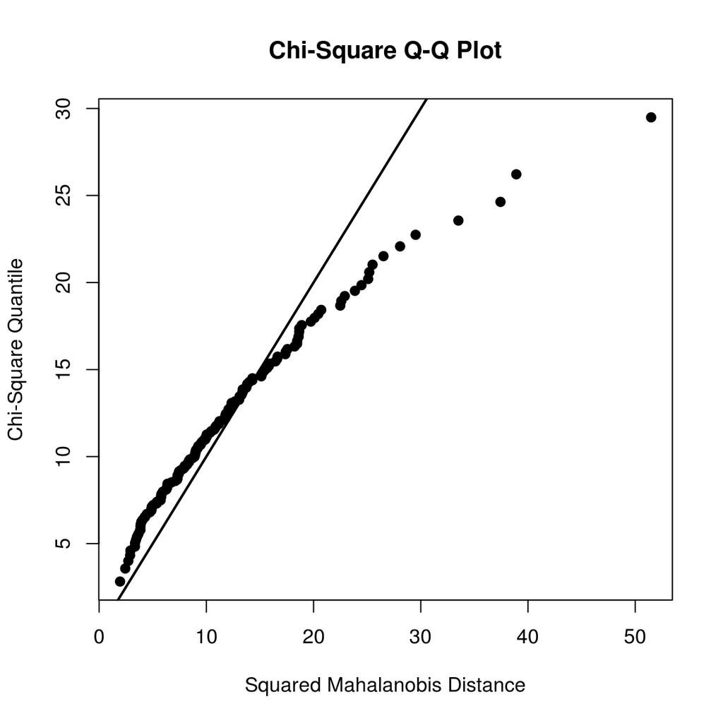

```
##    Mardia's Multivariate Normality Test
## ---------------------------------------
##    data : data1
##
##    g1p            : 29.99652
##    chi.skew       : 749.9129
##    p.value.skew   : 5.923668e-29
##
##    g2p            : 203.0284
##    z.kurtosis     : 11.70215
##    p.value.kurt   : 0
##
##    chi.small.skew : 767.2563
##    p.value.small  : 6.235697e-31
##
##    Result          : Data are not multivariate normal.
## ---------------------------------------
```

```r
mardiaTest(data1, qqplot = TRUE)
```

## 3.2 Step 1

1. Check suitability of data for analysis
1. Kaiser-Meyer-Olkin (KMO) Measure of Sampling Adequacy

```r
KMO(data1)  # middling
```

```
## Kaiser-Meyer-Olkin factor adequacy
## Call: KMO(r = data1)
## Overall MSA =  0.76
## MSA for each item =
##   Q1   Q2   Q3   Q4   Q5   Q6   Q7   Q8   Q9  Q10  Q11  Q12
## 0.34 0.83 0.64 0.75 0.83 0.81 0.82 0.81 0.68 0.70 0.82 0.68
```

2. Bartlet’s test of sphericity

```r
cortest.bartlett(data1)  # < 0.05 = sphericity assumption met
```

```
## R was not square, finding R from data
```

```
## $chisq
## [1] 562.3065
##
## $p.value
## [1] 7.851736e-80
##
## $df
## [1] 66
```

2. Determine the number of factors by
1. Eigenvalues
2. Scree plot

```r
scree = scree(data1)  # we are only concerned with FA scree & eigenvalues
```

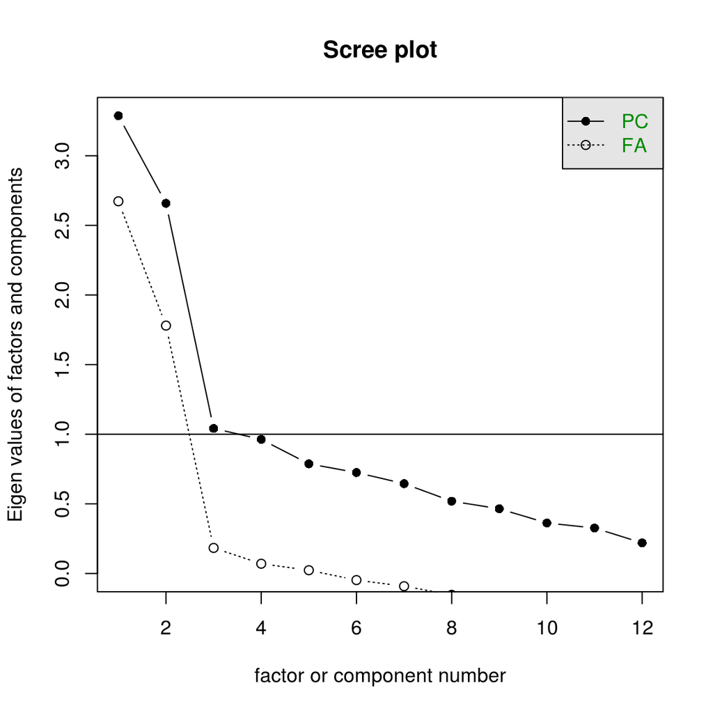

```r
print(scree)
```

```
## Scree of eigen values
## Call: NULL
## Eigen values of factors  [1]  2.67  1.78  0.18  0.07  0.02 -0.05 -0.09 -0.15 -0.20 -0.41 -0.46
## [12] -0.70
## Eigen values of Principal Components [1] 3.29 2.66 1.04 0.96 0.79 0.73 0.65 0.52 0.46 0.36 0.33 0.22
```

3. Parallel analysis

```r
parallel = fa.parallel(data1, fm = "pa", fa = "fa")
```

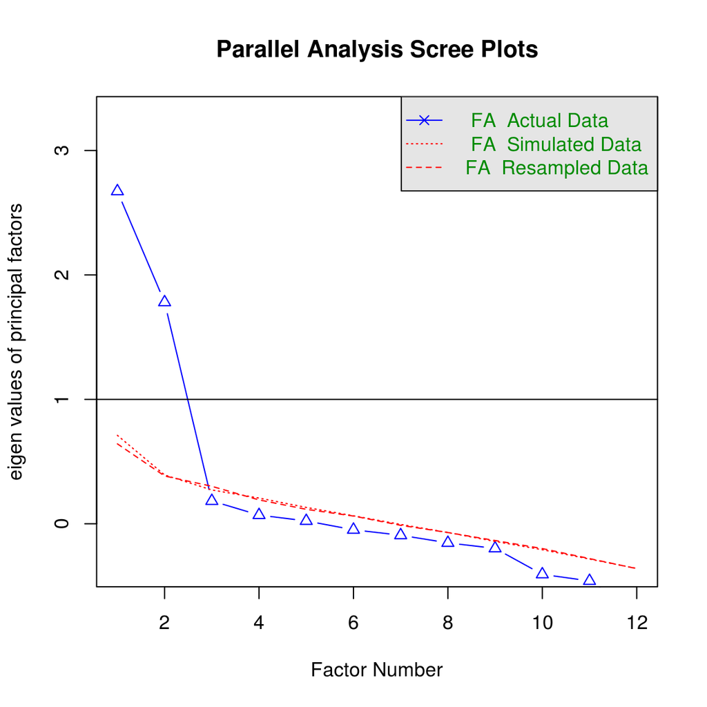

```
## Parallel analysis suggests that the number of factors =  2  and the number of components =  NA
```

```r
print(parallel)
```

```
## Call: fa.parallel(x = data1, fm = "pa", fa = "fa")
## Parallel analysis suggests that the number of factors =  2  and the number of components =  NA
##
##  Eigen Values of
##
##  eigen values of factors
##  [1]  2.67  1.78  0.18  0.07  0.02 -0.05 -0.09 -0.15 -0.20 -0.41 -0.46
## [12] -0.70
##
##  eigen values of simulated factors
##  [1]  0.71  0.39  0.27  0.21  0.13  0.06 -0.01 -0.07 -0.14 -0.21 -0.28
## [12] -0.36
##
##  eigen values of components
##  [1] 3.29 2.66 1.04 0.96 0.79 0.73 0.65 0.52 0.46 0.36 0.33 0.22
##
##  eigen values of simulated components
## [1] NA
```

## 3.3 Step 2

1. Run EFA by fixing number of factors as decided from previous step.
2. Decide on rotation method. Choose an oblique rotation, Promax.

```r
fa = fa(data1, nfactors = 2, rotate = "promax", fm = "pa")
print(fa)
```

```
## Factor Analysis using method =  pa
## Call: fa(r = data1, nfactors = 2, rotate = "promax", fm = "pa")
## Standardized loadings (pattern matrix) based upon correlation matrix
##       PA1   PA2     h2   u2 com
## Q1  -0.03  0.05 0.0037 1.00 1.6
## Q2   0.22  0.41 0.2071 0.79 1.5
## Q3  -0.28  0.44 0.2819 0.72 1.7
## Q4   0.81 -0.02 0.6585 0.34 1.0
## Q5   0.62  0.23 0.4169 0.58 1.3
## Q6   0.72  0.00 0.5251 0.47 1.0
## Q7   0.73 -0.04 0.5327 0.47 1.0
## Q8   0.31  0.66 0.5012 0.50 1.4
## Q9   0.12  0.77 0.5983 0.40 1.0
## Q10  0.06  0.88 0.7749 0.23 1.0
## Q11  0.54  0.10 0.2977 0.70 1.1
## Q12 -0.29  0.29 0.1767 0.82 2.0
##
##                        PA1  PA2
## SS loadings           2.68 2.30
## Proportion Var        0.22 0.19
## Cumulative Var        0.22 0.41
## Proportion Explained  0.54 0.46
## Cumulative Proportion 0.54 1.00
##
##  With factor correlations of
##       PA1   PA2
## PA1  1.00 -0.06
## PA2 -0.06  1.00
##
## Mean item complexity =  1.3
## Test of the hypothesis that 2 factors are sufficient.
##
## The degrees of freedom for the null model are  66  and the objective function was  3.9 with Chi Square of  562.31
## The degrees of freedom for the model are 43  and the objective function was  0.44
##
## The root mean square of the residuals (RMSR) is  0.05
## The df corrected root mean square of the residuals is  0.06
##
## The harmonic number of observations is  150 with the empirical chi square  41.53  with prob <  0.54
## The total number of observations was  150  with Likelihood Chi Square =  62.26  with prob <  0.029
##
## Tucker Lewis Index of factoring reliability =  0.94
## RMSEA index =  0.059  and the 90 % confidence intervals are  0.018 0.083
## BIC =  -153.19
## Fit based upon off diagonal values = 0.97
## Measures of factor score adequacy
##                                                 PA1  PA2
## Correlation of scores with factors             0.92 0.93
## Multiple R square of scores with factors       0.85 0.86
## Minimum correlation of possible factor scores  0.70 0.73
```

```r
print(fa, cut = .3, digits = 3)
```

```
## Factor Analysis using method =  pa
## Call: fa(r = data1, nfactors = 2, rotate = "promax", fm = "pa")
## Standardized loadings (pattern matrix) based upon correlation matrix
##        PA1    PA2      h2    u2  com
## Q1                0.00366 0.996 1.56
## Q2          0.413 0.20708 0.793 1.51
## Q3          0.437 0.28192 0.718 1.70
## Q4   0.810        0.65855 0.341 1.00
## Q5   0.616        0.41688 0.583 1.28
## Q6   0.725        0.52512 0.475 1.00
## Q7   0.726        0.53270 0.467 1.01
## Q8   0.306  0.655 0.50124 0.499 1.42
## Q9          0.771 0.59830 0.402 1.04
## Q10         0.882 0.77491 0.225 1.01
## Q11  0.542        0.29771 0.702 1.07
## Q12               0.17665 0.823 2.00
##
##                         PA1   PA2
## SS loadings           2.678 2.297
## Proportion Var        0.223 0.191
## Cumulative Var        0.223 0.415
## Proportion Explained  0.538 0.462
## Cumulative Proportion 0.538 1.000
##
##  With factor correlations of
##        PA1    PA2
## PA1  1.000 -0.055
## PA2 -0.055  1.000
##
## Mean item complexity =  1.3
## Test of the hypothesis that 2 factors are sufficient.
##
## The degrees of freedom for the null model are  66  and the objective function was  3.9 with Chi Square of  562.306
## The degrees of freedom for the model are 43  and the objective function was  0.436
##
## The root mean square of the residuals (RMSR) is  0.046
## The df corrected root mean square of the residuals is  0.057
##
## The harmonic number of observations is  150 with the empirical chi square  41.529  with prob <  0.535
## The total number of observations was  150  with Likelihood Chi Square =  62.265  with prob <  0.0288
##
## Tucker Lewis Index of factoring reliability =  0.9398
## RMSEA index =  0.0585  and the 90 % confidence intervals are  0.0184 0.0832
## BIC =  -153.192
## Fit based upon off diagonal values = 0.973
## Measures of factor score adequacy
##                                                  PA1   PA2
## Correlation of scores with factors             0.921 0.929
## Multiple R square of scores with factors       0.849 0.863
## Minimum correlation of possible factor scores  0.698 0.725
```

```r
# h2 = communalities
# u2 = error variance
```

3. Assess the results:
1. Judge the quality of items. Remove poor performing items.

> Communality? Q1 < Q12 < Q2 < .25 Pattern coeff/factor loading FL? Q1 < .3, Q12 < .4, Q2 & Q3 < .5
2. Check for overlap between factors.

## 3.4 Step 3

1. Re-run the analysis similar to Step 2 every time an item is removed. Make judgment based on the results.
2. The analysis is finished once we have:
- satisfactory number of factors.
- satisfactory quality of items.

**Decisions?**  
Remove Q1? Low com & FL

```r
fa1 = fa(data1[-1], nfactors = 2, rotate = "promax", fm = "pa")
print(fa1, cut = .3, digits = 3)
```

```
## Factor Analysis using method =  pa
## Call: fa(r = data1[-1], nfactors = 2, rotate = "promax", fm = "pa")
## Standardized loadings (pattern matrix) based upon correlation matrix
##        PA1    PA2    h2    u2  com
## Q2          0.417 0.207 0.793 1.33
## Q3  -0.324  0.426 0.280 0.720 1.87
## Q4   0.811        0.658 0.342 1.00
## Q5   0.590        0.417 0.583 1.35
## Q6   0.724        0.526 0.474 1.00
## Q7   0.731        0.534 0.466 1.00
## Q8          0.660 0.499 0.501 1.25
## Q9          0.774 0.601 0.399 1.00
## Q10         0.883 0.779 0.221 1.00
## Q11  0.531        0.298 0.702 1.09
## Q12 -0.316        0.175 0.825 1.97
##
##                         PA1   PA2
## SS loadings           2.643 2.329
## Proportion Var        0.240 0.212
## Cumulative Var        0.240 0.452
## Proportion Explained  0.532 0.468
## Cumulative Proportion 0.532 1.000
##
##  With factor correlations of
##       PA1   PA2
## PA1 1.000 0.022
## PA2 0.022 1.000
##
## Mean item complexity =  1.3
## Test of the hypothesis that 2 factors are sufficient.
##
## The degrees of freedom for the null model are  55  and the objective function was  3.86 with Chi Square of  557.828
## The degrees of freedom for the model are 34  and the objective function was  0.396
##
## The root mean square of the residuals (RMSR) is  0.047
## The df corrected root mean square of the residuals is  0.06
##
## The harmonic number of observations is  150 with the empirical chi square  36.112  with prob <  0.37
## The total number of observations was  150  with Likelihood Chi Square =  56.625  with prob <  0.00876
##
## Tucker Lewis Index of factoring reliability =  0.9265
## RMSEA index =  0.0702  and the 90 % confidence intervals are  0.0337 0.0967
## BIC =  -113.736
## Fit based upon off diagonal values = 0.976
## Measures of factor score adequacy
##                                                  PA1   PA2
## Correlation of scores with factors             0.921 0.931
## Multiple R square of scores with factors       0.848 0.866
## Minimum correlation of possible factor scores  0.697 0.733
```

Remove Q12? Low com & FL

```r
fa2 = fa(data1[-c(1,12)], nfactors = 2, rotate = "promax", fm = "pa")
print(fa2, cut = .3, digits = 3)
```

```
## Factor Analysis using method =  pa
## Call: fa(r = data1[-c(1, 12)], nfactors = 2, rotate = "promax", fm = "pa")
## Standardized loadings (pattern matrix) based upon correlation matrix
##        PA1    PA2    h2    u2  com
## Q2          0.417 0.211 0.789 1.23
## Q3  -0.319  0.417 0.239 0.761 1.87
## Q4   0.844        0.702 0.298 1.01
## Q5   0.594        0.426 0.574 1.23
## Q6   0.709        0.501 0.499 1.00
## Q7   0.735        0.531 0.469 1.02
## Q8          0.658 0.507 0.493 1.18
## Q9          0.781 0.608 0.392 1.00
## Q10         0.895 0.789 0.211 1.02
## Q11  0.529        0.298 0.702 1.05
##
##                         PA1   PA2
## SS loadings           2.558 2.251
## Proportion Var        0.256 0.225
## Cumulative Var        0.256 0.481
## Proportion Explained  0.532 0.468
## Cumulative Proportion 0.532 1.000
##
##  With factor correlations of
##       PA1   PA2
## PA1 1.000 0.135
## PA2 0.135 1.000
##
## Mean item complexity =  1.2
## Test of the hypothesis that 2 factors are sufficient.
##
## The degrees of freedom for the null model are  45  and the objective function was  3.603 with Chi Square of  521.821
## The degrees of freedom for the model are 26  and the objective function was  0.275
##
## The root mean square of the residuals (RMSR) is  0.039
## The df corrected root mean square of the residuals is  0.052
##
## The harmonic number of observations is  150 with the empirical chi square  20.882  with prob <  0.748
## The total number of observations was  150  with Likelihood Chi Square =  39.525  with prob <  0.0434
##
## Tucker Lewis Index of factoring reliability =  0.9504
## RMSEA index =  0.0623  and the 90 % confidence intervals are  0.0105 0.0944
## BIC =  -90.752
## Fit based upon off diagonal values = 0.985
## Measures of factor score adequacy
##                                                  PA1   PA2
## Correlation of scores with factors             0.925 0.934
## Multiple R square of scores with factors       0.855 0.872
## Minimum correlation of possible factor scores  0.711 0.744
```

Remove Q2? Low com & FL

```r
fa3 = fa(data1[-c(1,2,12)], nfactors = 2, rotate = "promax", fm = "pa")
print(fa3, cut = .3, digits = 3)
```

```
## Factor Analysis using method =  pa
## Call: fa(r = data1[-c(1, 2, 12)], nfactors = 2, rotate = "promax",
##     fm = "pa")
## Standardized loadings (pattern matrix) based upon correlation matrix
##        PA1    PA2    h2    u2  com
## Q3          0.402 0.229 0.771 1.80
## Q4   0.841        0.705 0.295 1.01
## Q5   0.617        0.438 0.562 1.22
## Q6   0.706        0.496 0.504 1.00
## Q7   0.727        0.528 0.472 1.02
## Q8          0.621 0.465 0.535 1.31
## Q9          0.791 0.635 0.365 1.01
## Q10         0.905 0.819 0.181 1.00
## Q11  0.534        0.295 0.705 1.04
##
##                         PA1   PA2
## SS loadings           2.552 2.059
## Proportion Var        0.284 0.229
## Cumulative Var        0.284 0.512
## Proportion Explained  0.553 0.447
## Cumulative Proportion 0.553 1.000
##
##  With factor correlations of
##       PA1   PA2
## PA1 1.000 0.062
## PA2 0.062 1.000
##
## Mean item complexity =  1.2
## Test of the hypothesis that 2 factors are sufficient.
##
## The degrees of freedom for the null model are  36  and the objective function was  3.362 with Chi Square of  488.011
## The degrees of freedom for the model are 19  and the objective function was  0.213
##
## The root mean square of the residuals (RMSR) is  0.037
## The df corrected root mean square of the residuals is  0.051
##
## The harmonic number of observations is  150 with the empirical chi square  14.815  with prob <  0.734
## The total number of observations was  150  with Likelihood Chi Square =  30.579  with prob <  0.0449
##
## Tucker Lewis Index of factoring reliability =  0.951
## RMSEA index =  0.0669  and the 90 % confidence intervals are  0.0099 0.1042
## BIC =  -64.623
## Fit based upon off diagonal values = 0.988
## Measures of factor score adequacy
##                                                  PA1   PA2
## Correlation of scores with factors             0.925 0.939
## Multiple R square of scores with factors       0.855 0.882
## Minimum correlation of possible factor scores  0.711 0.764
```

Remove Q3? Low com & FL

```r
fa4 = fa(data1[-c(1,2,3,12)], nfactors = 2, rotate = "promax", fm = "pa")
print(fa4, cut = .3, digits = 3)
```

```
## Factor Analysis using method =  pa
## Call: fa(r = data1[-c(1, 2, 3, 12)], nfactors = 2, rotate = "promax",
##     fm = "pa")
## Standardized loadings (pattern matrix) based upon correlation matrix
##        PA1    PA2    h2    u2  com
## Q4   0.830        0.664 0.336 1.02
## Q5   0.607        0.447 0.553 1.16
## Q6   0.712        0.494 0.506 1.01
## Q7   0.760        0.549 0.451 1.05
## Q8          0.633 0.471 0.529 1.12
## Q9          0.862 0.717 0.283 1.02
## Q10         0.876 0.733 0.267 1.04
## Q11  0.533        0.299 0.701 1.02
##
##                         PA1   PA2
## SS loadings           2.440 1.935
## Proportion Var        0.305 0.242
## Cumulative Var        0.305 0.547
## Proportion Explained  0.558 0.442
## Cumulative Proportion 0.558 1.000
##
##  With factor correlations of
##       PA1   PA2
## PA1 1.000 0.235
## PA2 0.235 1.000
##
## Mean item complexity =  1.1
## Test of the hypothesis that 2 factors are sufficient.
##
## The degrees of freedom for the null model are  28  and the objective function was  3.025 with Chi Square of  440.182
## The degrees of freedom for the model are 13  and the objective function was  0.101
##
## The root mean square of the residuals (RMSR) is  0.031
## The df corrected root mean square of the residuals is  0.045
##
## The harmonic number of observations is  150 with the empirical chi square  7.868  with prob <  0.852
## The total number of observations was  150  with Likelihood Chi Square =  14.54  with prob <  0.337
##
## Tucker Lewis Index of factoring reliability =  0.9919
## RMSEA index =  0.0324  and the 90 % confidence intervals are  0 0.0885
## BIC =  -50.598
## Fit based upon off diagonal values = 0.993
## Measures of factor score adequacy
##                                                  PA1   PA2
## Correlation of scores with factors             0.919 0.929
## Multiple R square of scores with factors       0.845 0.863
## Minimum correlation of possible factor scores  0.691 0.726
```

## 3.5 Summary:

```
PA1 =~ Q4, Q5, Q6, Q7, Q11
PA2 =~ Q8, Q9, Q10
```

Name the factor.

# 4 Cronbach’s alpha

Determine the reliability for each factor separately by including the selected items only.

```r
names(data1)
```

```
##  [1] "Q1"  "Q2"  "Q3"  "Q4"  "Q5"  "Q6"  "Q7"  "Q8"  "Q9"  "Q10" "Q11"
## [12] "Q12"
```

```r
PA1 = c("Q4","Q5","Q6","Q7","Q11")
PA2 = c("Q8","Q9","Q10")
```

**PA1**

```r
alpha.pa1 = alpha(data1[PA1])
print(alpha.pa1)
```

```
##
## Reliability analysis
## Call: alpha(x = data1[PA1])
##
##   raw_alpha std.alpha G6(smc) average_r S/N   ase mean   sd
##       0.82      0.82    0.79      0.47 4.4 0.023  3.1 0.82
##
##  lower alpha upper     95% confidence boundaries
## 0.77 0.82 0.86
##
##  Reliability if an item is dropped:
##     raw_alpha std.alpha G6(smc) average_r S/N alpha se
## Q4       0.75      0.75    0.70      0.43 3.0    0.033
## Q5       0.79      0.79    0.75      0.48 3.7    0.027
## Q6       0.78      0.78    0.74      0.46 3.5    0.029
## Q7       0.77      0.77    0.73      0.46 3.4    0.030
## Q11      0.81      0.81    0.77      0.51 4.2    0.025
##
##  Item statistics
##       n raw.r std.r r.cor r.drop mean   sd
## Q4  150  0.84  0.82  0.78   0.71  2.8 1.17
## Q5  150  0.72  0.74  0.63   0.57  3.3 1.01
## Q6  150  0.77  0.77  0.69   0.62  3.1 1.09
## Q7  150  0.79  0.78  0.71   0.64  2.9 1.19
## Q11 150  0.66  0.69  0.56   0.50  3.4 0.94
##
## Non missing response frequency for each item
##        1    2    3    4    5 miss
## Q4  0.14 0.28 0.30 0.19 0.09    0
## Q5  0.04 0.17 0.35 0.33 0.11    0
## Q6  0.08 0.23 0.33 0.26 0.09    0
## Q7  0.13 0.27 0.23 0.29 0.08    0
## Q11 0.03 0.15 0.35 0.39 0.09    0
```

```r
# r.drop = Corrected item-total correlation
# raw_alpha = Cronbach's alpha if item deleted
```

```r
# Squared Multiple Correlation (smc)
smc(data1[c(4,5,6,7,11)])
```

```
##        Q4        Q5        Q6        Q7       Q11
## 0.5101317 0.3453175 0.4152712 0.4501847 0.2754991
```

**PA2**

```r
alpha.pa2 = alpha(data1[PA2])
print(alpha.pa2)
```

```
##
## Reliability analysis
## Call: alpha(x = data1[PA2])
##
##   raw_alpha std.alpha G6(smc) average_r S/N   ase mean  sd
##       0.83      0.82    0.77      0.61 4.7 0.025  3.4 0.9
##
##  lower alpha upper     95% confidence boundaries
## 0.78 0.83 0.87
##
##  Reliability if an item is dropped:
##     raw_alpha std.alpha G6(smc) average_r S/N alpha se
## Q8       0.84      0.84    0.73      0.73 5.3    0.026
## Q9       0.72      0.72    0.56      0.56 2.5    0.046
## Q10      0.71      0.71    0.55      0.55 2.4    0.048
##
##  Item statistics
##       n raw.r std.r r.cor r.drop mean  sd
## Q8  150  0.81  0.82  0.65   0.60  3.3 1.0
## Q9  150  0.88  0.88  0.81   0.73  3.4 1.0
## Q10 150  0.89  0.88  0.82   0.73  3.3 1.1
##
## Non missing response frequency for each item
##        1    2    3    4    5 miss
## Q8  0.05 0.10 0.48 0.23 0.15    0
## Q9  0.05 0.09 0.42 0.25 0.19    0
## Q10 0.07 0.11 0.42 0.23 0.17    0
```

```r
smc(data1[c(8,9,10)])
```

```
##        Q8        Q9       Q10
## 0.3556869 0.5557379 0.5633902
```